# OBER project BODAC filters and water

Pieter van Veelen

5/21/2021

## R Markdown

Analysis of microbial communities in BODAC filters and backwash water. Evaluate the effects of different DNA extraction methods. Pre-filters and polishing filters are referred to as BODAC1 and BODAC2, respectively, in the manuscript text and in figures (adjusted using Illustrator pre-submission).

### Set parameters and import data

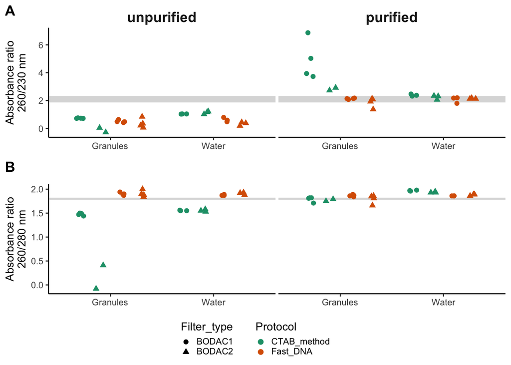

```r
purity_260_230 =
metadata_dna %>%
  filter(Purification == purif_state,
         waves == "absorb_260_230") %>%
  mutate(Purification = fct_relevel(Purification, c("unpurified", "purified"))) %>%
  #pivot_wider(names_from = waves, values_from = Absorbance_ratio)
  #filter(Purification == "unpurified") %>%
  ggplot(aes(x = Sample_type, y = Absorbance_ratio)) +
  geom_abline(intercept = 2.1, slope =0, size=3, color = "grey80", alpha = 0.7) +
  geom_point(aes(color = Protocol, shape = Filter_type),
             position = position_jitterdodge(0.2), show.legend = T, size = 2) +
  scale_color_manual(values = c(brewer.pal(2, "Dark2"))) +
  labs(y = "Absorbance ratio\n260/230 nm", x = NULL) +
  guides(colour = guide_legend(title.position = "top"),
         size = guide_legend(title.position = "top")) +
  #stat_summary(fun = median, pch = 21) +
  facet_wrap(nrow = 2, ncol = 2, ~ Purification, strip.position = "top") +
  theme_classic() +
  theme(axis.text.x = element_markdown(),
        legend.text = element_markdown(),
        legend.key.size = unit(10, "pt"),
        strip.placement = "outer",
        strip.background = element_blank(),
        strip.text.x = element_text(size = 14, face = "bold"),
        panel.spacing = unit(0.2, "lines"))
  #theme(legend.position = "bottom") +
  #theme(axis.text.x = element_text(angle = 90, hjust=1))


purity_260_280 =
metadata_dna %>%
  filter(Purification == purif_state,
         waves == "absorb_260_280") %>%
  mutate(Purification = fct_relevel(Purification, c("unpurified", "purified"))) %>%
  #pivot_wider(names_from = waves, values_from = Absorbance_ratio)
  #filter(Purification == "unpurified") %>%
  ggplot(aes(x = Sample_type, y = Absorbance_ratio)) +
  geom_abline(intercept = 1.8, slope =0, size=1, color = "grey80", alpha = 0.7) +
  geom_point(aes(color = Protocol, shape = Filter_type),
             position = position_jitterdodge(0.2), show.legend = T, size = 2) +
  scale_color_manual(values = c(brewer.pal(2, "Dark2"))) +
  #stat_summary(fun = median, pch = 21) +
  facet_wrap(nrow = 2, ncol = 2, ~ Purification, strip.position = "top") +
  labs(y = "Absorbance ratio\n260/280 nm", x = NULL) +
  guides(colour = guide_legend(title.position = "top"),
         size = guide_legend(title.position = "top")) +
  theme_classic() +
  theme(axis.text.x = element_markdown(),
        legend.text = element_markdown(),
        legend.key.size = unit(10, "pt"),
        strip.text = element_blank(), # redundant in B
        strip.placement = "outer",
        strip.background = element_blank(),
        #strip.text.x = element_text(size = 14, face = "bold"),
        panel.spacing = unit(0.2, "lines"))
  #theme(legend.position = "bottom") +
  #theme(axis.text.x = element_text(angle = 90, hjust=1))

# extract plots without legend
purity_plots = plot_grid(purity_260_230 + theme(legend.position = "none"),
                         purity_260_280 + theme(legend.position = "none"),
                         labels  = c("A", "B"),
                         nrow = 2,
                         align = "hv")

# extract legend
legend_purity <- get_legend(purity_260_280 + guides(color = guide_legend(ncol = 1),
                                             shape = guide_legend(ncol = 1)) +
                            theme(legend.position = "bottom",
                                  legend.direction = "vertical"))

# shape figure with plots and legend
purity_fig <- plot_grid(purity_plots, legend_purity, nrow=2, rel_heights = c(6, 1))
purity_fig
```

```r
# save figure
ggsave(plot = purity_fig, filename = "figures/Fig_1_OBER_DNA_purity.pdf", width = 6, height = 5)
```

#### Analysis of DNA concentrations

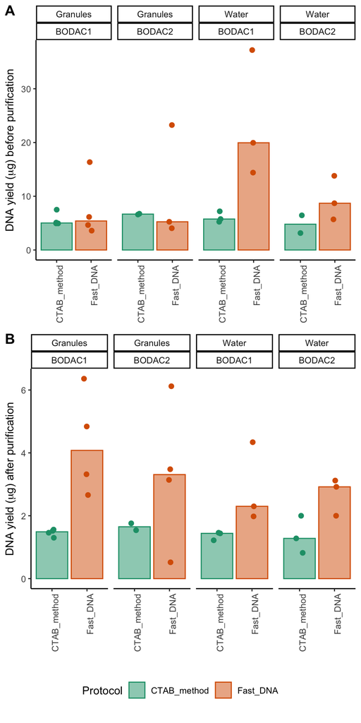

```r
# plot DNA concentration unpurified only
unpurified_yield <-
metadata_dna %>%
  mutate(dna_amount_ng = ifelse(Purification == "unpurified", DNA_conc_ng_ul*30,
                                DNA_conc_ng_ul*20)) %>%
  filter(Purification == "unpurified") %>%
  select(SampleID, Sample_type, Filter_type, Protocol, dna_amount_ng) %>%
  distinct() %>%
  ggplot(aes(x = Protocol, y = dna_amount_ng/1000, color = Protocol, fill = Protocol)) +
  stat_summary(fun = median, geom = "bar", alpha = 0.5) +
  geom_point(size = 2, position = position_jitterdodge(0.2), show.legend = F) +
  scale_color_manual(values = c(brewer.pal(2, "Dark2"))) +
  scale_fill_manual(values = c(brewer.pal(2, "Dark2"))) +
  facet_grid(~Sample_type + Filter_type) +
  theme_classic() +
  labs(y = expression(paste("DNA yield (",mu,"g) before purification")), x = NULL) +
  #theme(legend.position = "bottom") +
  #ggtitle("DNA yield before purification") +
  theme(axis.text.x = element_text(angle = 90, hjust = 1))
# plot DNA concentration purified only
purified_yield <-
metadata_dna %>%
  mutate(dna_amount_ng = ifelse(Purification == "unpurified", DNA_conc_ng_ul*30,
                                DNA_conc_ng_ul*20)) %>%
  filter(Purification == "purified") %>%
  select(SampleID, Sample_type, Filter_type, Protocol, dna_amount_ng) %>%
  distinct() %>%
  ggplot(aes(x = Protocol, y = dna_amount_ng/1000, color = Protocol, fill=Protocol)) +
  stat_summary(fun = median, geom = "bar", alpha = 0.5) +
  geom_point(size = 2, position = position_jitterdodge(0.2), show.legend = F) +
  scale_color_manual(values = c(brewer.pal(2, "Dark2"))) +
  scale_fill_manual(values = c(brewer.pal(2, "Dark2"))) +
  facet_grid(~Sample_type + Filter_type) +
  theme_classic() +
  labs(y = expression(paste("DNA yield (",mu,"g) after purification")), x = NULL) +
  #theme(legend.position = "bottom") +
  #ggtitle("DNA yield after purification") +
  theme(axis.text.x = element_text(angle = 90, hjust = 1))
# DNA yield plot
plot_fig <- cowplot::plot_grid(unpurified_yield + theme(legend.position = "none"),
                               purified_yield + theme(legend.position = "none"),
                               get_legend(unpurified_yield +
                                            theme(legend.position = "bottom",
                                                  legend.direction = "horizontal")),
                               labels = c("A", "B"),
                               nrow = 3,
                               rel_heights = c(1, 1, 0.2))
# show plot
plot_fig
```

```r
# save plot
ggsave(plot_fig, filename = "figures/Figure_2_DNA_quantity.pdf", width = 4, height = 9)
```

```r
# tabulate loss
metadata_dna_ %>%
  mutate(loss_ng = (purified*20)-(unpurified*30)) %>%
  group_by(Protocol, Sample_type, Filter_type) %>%
  summarize(median_hilow(loss_ng))
```

```
## # A tibble: 9 × 6
## # Groups:   Protocol, Sample_type [4]
##   Protocol    Sample_type Filter_type           y    ymin    ymax
##   <chr>       <chr>       <chr>             <dbl>   <dbl>   <dbl>
## 1 CTAB_method Granules    Polishing_filter  -5025  -5201.  -4849.
## 2 CTAB_method Granules    Pre-filter        -3615  -5872   -3393
## 3 CTAB_method Water       Polishing_filter  -3160  -4386.  -1934.
## 4 CTAB_method Water       Pre-filter        -4300  -5687   -4044.
## 5 Fast_DNA    Granules    Polishing_filter  -2110 -16379    -647
## 6 Fast_DNA    Granules    Pre-filter        -2410 -10908.   2453.
## 7 Fast_DNA    Water       Blank                NA     NA      NA
## 8 Fast_DNA    Water       Polishing_filter  -5780 -10435   -3804
## 9 Fast_DNA    Water       Pre-filter       -17650 -34342. -10439.
```

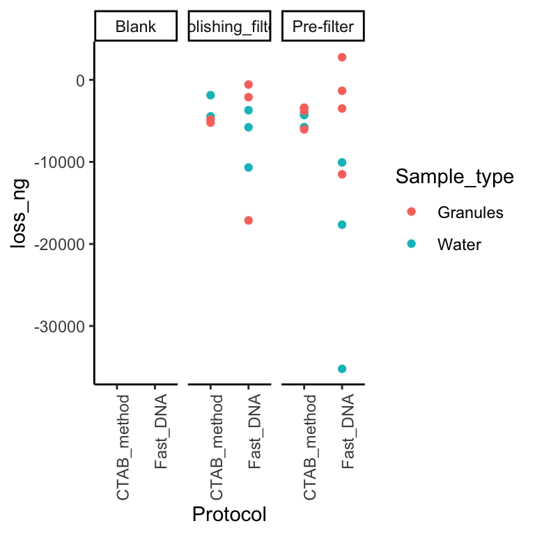

```r
# plot loss
metadata_dna_ %>%
  mutate(loss_ng = (purified*20)-(unpurified*30)) %>%
  ggplot(aes(y = loss_ng, x = Protocol, color = Sample_type)) +
  geom_point() +
  facet_wrap(~Filter_type) +
  theme_classic() +
  theme(axis.text.x = element_text(angle = 90, hjust = 1))
```

```r
# statistics
# unpurified
# water only
metadata_dna %>%
  mutate(dna_amount_ng = ifelse(Purification == "unpurified", DNA_conc_ng_ul*30,
                                DNA_conc_ng_ul*20)) %>%
  select(SampleID, Purification, Sample_type, Filter_type, Protocol, dna_amount_ng) %>%
  distinct() %>%
  filter(Purification == "unpurified",
         Sample_type == "Water") %>%
  with(kruskal.test(dna_amount_ng ~ Protocol))
```

```
##
##  Kruskal-Wallis rank sum test
##
## data:  dna_amount_ng by Protocol
## Kruskal-Wallis chi-squared = 4.8, df = 1, p-value = 0.02846
```

```r
# granules
metadata_dna %>%
  mutate(dna_amount_ng = ifelse(Purification == "unpurified", DNA_conc_ng_ul*30,
                                DNA_conc_ng_ul*20)) %>%
  select(SampleID, Purification, Sample_type, Filter_type, Protocol, dna_amount_ng) %>%
  distinct() %>%
  filter(Purification == "unpurified",
         Sample_type == "Granules") %>%
  with(kruskal.test(dna_amount_ng ~ Protocol))
```

```
##
##  Kruskal-Wallis rank sum test
##
## data:  dna_amount_ng by Protocol
## Kruskal-Wallis chi-squared = 0.18418, df = 1, p-value = 0.6678
```

```r
#purified
# water only
metadata_dna %>%
  mutate(dna_amount_ng = ifelse(Purification == "unpurified", DNA_conc_ng_ul*30,
                                DNA_conc_ng_ul*20)) %>%
  select(SampleID, Purification, Sample_type, Filter_type, Protocol, dna_amount_ng) %>%
  distinct() %>%
  filter(Purification == "purified",
         Sample_type == "Water") %>%
  with(kruskal.test(dna_amount_ng ~ Protocol))
```

```
##
##  Kruskal-Wallis rank sum test
##
## data:  dna_amount_ng by Protocol
## Kruskal-Wallis chi-squared = 7.0053, df = 1, p-value = 0.008127
```

```r
# granules only
metadata_dna %>%
  mutate(dna_amount_ng = ifelse(Purification == "unpurified", DNA_conc_ng_ul*30,
                                DNA_conc_ng_ul*20)) %>%
  select(SampleID, Purification, Sample_type, Filter_type, Protocol, dna_amount_ng) %>%
  distinct() %>%
  filter(Purification == "purified",
         Sample_type == "Granules") %>%
  with(kruskal.test(dna_amount_ng ~ Protocol))
```

```
##
##  Kruskal-Wallis rank sum test
##
## data:  dna_amount_ng by Protocol
## Kruskal-Wallis chi-squared = 5.4, df = 1, p-value = 0.02014
```

```r
### read in new purity data by OBER
# Test for differences in purity between purified and unpurified samples stratified by granules and water, and without blanks.
```

#### calculate rarefaction curves using amp_rarecurve.r

```r
# full dataset
psdata_OBER
```

```
## phyloseq-class experiment-level object
## otu_table()   OTU Table:         [ 3009 taxa and 34 samples ]
## sample_data() Sample Data:       [ 34 samples by 11 sample variables ]
## tax_table()   Taxonomy Table:    [ 3009 taxa by 7 taxonomic ranks ]
## phy_tree()    Phylogenetic Tree: [ 3009 tips and 3008 internal nodes ]
```

```r
psdata_OBER <- subset_samples(psdata_OBER, Filter_type != "Blank")

# average and variation in coverage
mean(sample_sums(psdata_OBER)) # = 69797.76
```

```
## [1] 71896.55
```

```r
summary(sample_sums(psdata_OBER))
```

```
##    Min. 1st Qu.  Median    Mean 3rd Qu.    Max.
##   17034   66238   75046   71897   80291   98398
```

```r
sum(sample_sums(psdata_OBER))
```

```
## [1] 2372586
```

```r
# number of reads in Blank (#538)
sample_sums(subset_samples(physeq2, Filter_type == "Blank"))
```

```
## OBER.36
##     538
```

```r
# relative abundance data
psdata_OBER_rel <- transform_sample_counts(psdata_OBER, fun = function(x) x/sum(x)) # 3009 taxa (100% abundance)

# abundance filter at (0.01%, 0.1% 0.5%)
psdata_OBER_0.01pct <- prune_taxa(taxa_sums(psdata_OBER_rel) > 0.0001, psdata_OBER) #2610 (99.94% abundance)
psdata_OBER_0.1pct <- prune_taxa(taxa_sums(psdata_OBER_rel) > 0.001, psdata_OBER) #1615 (98.73% abundance)
psdata_OBER_0.5pct <- prune_taxa(taxa_sums(psdata_OBER_rel) > 0.005, psdata_OBER) #2610 (93.07% abundance)

### choice to continue downstream analysis with abundance filter that retains ASVs with at least 0.1% of total read abundance.
psdata_OBER_unfiltered <- psdata_OBER # save unfiltered data
psdata_OBER <- psdata_OBER_0.1pct # overwrite psdata_OBER for abundance filtered data

# reformat metadata
metadata <- data.frame(sample_data(psdata_OBER), stringsAsFactors = T)
metadata$Sample_type <- as.factor(metadata$Sample_type)
metadata$Filter_type <- as.factor(metadata$Filter_type)
metadata$Time <- as.factor(metadata$Time)
metadata$Protocol <- as.factor(metadata$Protocol)
```

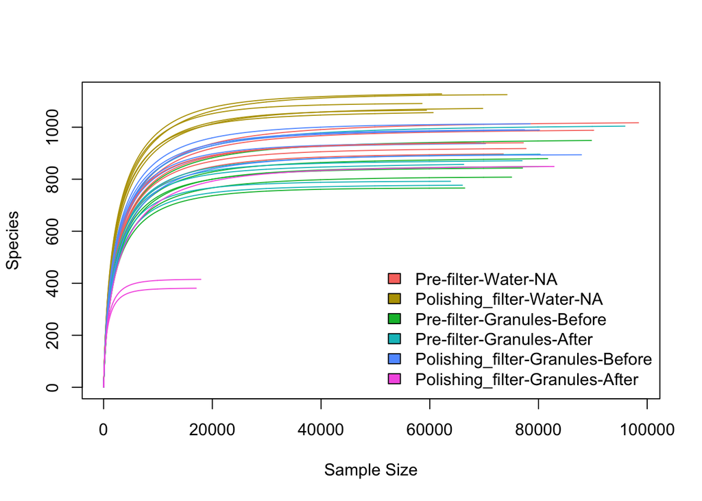

```r
# alpha rarefaction curve
source("scripts/ampvis2_internals.r")
source("scripts/amp_rankabundance.r")
source("scripts/amp_rarecurve.r")

# show plot
amp_rarecurve(psdata_OBER_unfiltered, color = "combined", legend.position = "bottomright")
```

```r
# save plot
pdf("figures/OBER_proj1_BODAC_rarefaction_curves.pdf", useDingbats = F, width = 6, height = 4)
amp_rarecurve(psdata_OBER_unfiltered, color = "combined", legend.position = "bottomright")
dev.off()
```

```r
#amp_rarecurve(psdata_OBER, color = "combined", legend.position = "bottomright")
#amp_rarecurve(psdata_OBER, color = "Protocol", legend.position = "bottomright")

# difference in sample coverage (5.75)
max(sample_sums(psdata_OBER)/min(sample_sums(psdata_OBER)))
```

```
## [1] 5.752387
```

```r
# summary statistics of dataset
summary(sample_sums(psdata_OBER)) %>%
  enframe(name = "statistic", value = "read count") %>%
  as_tibble() %>% kableExtra::kbl(caption = "summary statistics of sequence data set", centering = T, align = "l") %>% kableExtra::kable_classic()
```

summary statistics of sequence data set

| statistic | read count |
| --- | --- |
| Min. | 16865 |
| 1st Qu. | 65896 |
| Median | 74656 |
| Mean | 70994 |
| 3rd Qu. | 79842 |
| Max. | 97014 |

```r
# rarefy to 16865
  # create subset frequency matrix
  OBER_matrix <- as.matrix(t(otu_table(psdata_OBER)))

  # determine minimal sampling depth
  min_sample <- min(sample_sums(psdata_OBER))

  # rarefaction taking mean of 100 iterations
  set.seed(711)
  # OBER_rare16865 <- avgdist(OBER_matrix, d_method="bray", sample = min_sample, iterations = 100)
  # not using this: we also aim to calculate UniFrac
  source("scripts/avgrarefy.r")
  OBER_rare16865_table = avgrarefy(x=OBER_matrix, sample = min_sample, iterations = 100, seed = 711)


# create phyloseq object with rarefied data
psdata_OBER_rare <- psdata_OBER
otu_rare = otu_table(data.frame(t(OBER_rare16865_table)), taxa_are_rows = TRUE)
otu_table(psdata_OBER_rare) <- otu_rare
```

```r
# calculate alpha diversity: richness & Shannon

# rarefied
alpha <- estimate_richness(psdata_OBER_rare, measures = c("Chao1", "Shannon"))
alpha$sampleID <- row.names(alpha)
metadata$sampleID <- sample_names(psdata_OBER_rare)
alpha <- left_join(metadata, alpha, by = "sampleID")
alpha <- alpha %>% mutate(combined = factor(combined, levels=
                                c("Pre-filter-Granules-Before",
                                  "Pre-filter-Granules-After",
                                  "Polishing_filter-Granules-Before",
                                  "Polishing_filter-Granules-After",
                                  "Pre-filter-Water-NA",
                                  "Polishing_filter-Water-NA")))


alpha %>%
  group_by(Sample_type, Filter_type, Time, Protocol) %>%
  summarize(n())
```

```
## # A tibble: 11 × 5
## # Groups:   Sample_type, Filter_type, Time [6]
##    Sample_type Filter_type      Time   Protocol    `n()`
##    <fct>       <fct>            <fct>  <fct>       <int>
##  1 Granules    Polishing_filter After  Fast_DNA        3
##  2 Granules    Polishing_filter Before CTAB_method     3
##  3 Granules    Polishing_filter Before Fast_DNA        3
##  4 Granules    Pre-filter       After  CTAB_method     3
##  5 Granules    Pre-filter       After  Fast_DNA        3
##  6 Granules    Pre-filter       Before CTAB_method     3
##  7 Granules    Pre-filter       Before Fast_DNA        3
##  8 Water       Polishing_filter <NA>   CTAB_method     3
##  9 Water       Polishing_filter <NA>   Fast_DNA        3
## 10 Water       Pre-filter       <NA>   CTAB_method     3
## 11 Water       Pre-filter       <NA>   Fast_DNA        3
```

```r
alpha %>%
  pull(combined) %>% levels()
```

```
## [1] "Pre-filter-Granules-Before"       "Pre-filter-Granules-After"
## [3] "Polishing_filter-Granules-Before" "Polishing_filter-Granules-After"
## [5] "Pre-filter-Water-NA"              "Polishing_filter-Water-NA"
```

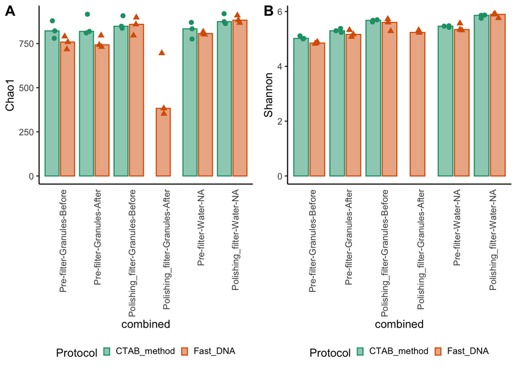

```r
# plot alpha diversity
Chao1 <- alpha %>%
ggplot(aes(x=combined, y=Chao1, color = Protocol, shape = Protocol, fill = Protocol)) +
  stat_summary(fun = median, geom = "bar", alpha = 0.5, position = position_dodge2(0.7, preserve = "single"), width=0.9) +
  geom_point(size = 2, position = position_jitterdodge(0.2), show.legend = F) +
  scale_color_manual(values = c(brewer.pal(6, "Dark2"))) +
  scale_fill_manual(values = c(brewer.pal(6, "Dark2"))) +
  theme_classic() +
  theme(axis.text.x = element_text(angle = 90, hjust = 1)) +
  theme(legend.text = element_markdown(),
        legend.key.size = unit(7, "pt"),
        axis.ticks.x = element_blank(),
        strip.background = element_blank(),
        strip.placement = "outside",
        legend.position = "bottom")

Shannon <- alpha %>%
ggplot(aes(x=combined, y=Shannon, color = Protocol, shape = Protocol, fill = Protocol)) +
  stat_summary(fun = median, geom = "bar", alpha = 0.5, position = position_dodge2(0.7, preserve = "single"), width=0.9) +
  geom_point(size = 2, position = position_jitterdodge(0.3), show.legend = F) +
  scale_color_manual(values = c(brewer.pal(6, "Dark2"))) +
  scale_fill_manual(values = c(brewer.pal(6, "Dark2"))) +
  theme_classic() +
  theme(axis.text.x = element_text(angle = 90, hjust = 1)) +
  theme(legend.text = element_markdown(),
        legend.key.size = unit(7, "pt"),
        axis.ticks.x = element_blank(),
        strip.background = element_blank(),
        strip.placement = "outside",
        legend.position = "bottom")

# create plot
alpha_div_rare = plot_grid(Chao1, Shannon, labels  = c("A", "B"), ncol = 2)

# show plot
alpha_div_rare
```

```r
# save plot
ggsave(alpha_div_rare, filename = "figures/plot_alpha_div_OBER_rare16865.pdf", width = 8, height = 6)
```

Chao1 richness statistics

| term | df | sumsq | meansq | statistic | p.value |
| --- | --- | --- | --- | --- | --- |
| Filter_type | 1 | 971.083 | 971.083 | 0.073 | 0.789 |
| Sample_type | 1 | 54025.179 | 54025.179 | 4.050 | 0.054 |
| Protocol | 1 | 63231.554 | 63231.554 | 4.740 | 0.038 |
| Residuals | 29 | 386838.936 | 13339.274 | NA | NA |

Shannon diversity statistics

| term | df | sumsq | meansq | statistic | p.value |
| --- | --- | --- | --- | --- | --- |
| Filter_type | 1 | 1.447 | 1.447 | 60.001 | 0.000 |
| Sample_type | 1 | 0.901 | 0.901 | 37.373 | 0.000 |
| Protocol | 1 | 0.129 | 0.129 | 5.370 | 0.028 |
| Residuals | 29 | 0.699 | 0.024 | NA | NA |

Difference Chao1 richness between BODAC1 and BODAC2 before backwashing

| term | df | sumsq | meansq | statistic | p.value |
| --- | --- | --- | --- | --- | --- |
| Filter_type | 1 | 13606.556 | 13606.556 | 6.832 | 0.059 |
| Residuals | 4 | 7966.872 | 1991.718 | NA | NA |

Difference Shannon diversity between BODAC1 and BODAC2 before backwashing

| term | df | sumsq | meansq | statistic | p.value |
| --- | --- | --- | --- | --- | --- |
| Filter_type | 1 | 0.700 | 0.700 | 26.828 | 0.007 |
| Residuals | 4 | 0.104 | 0.026 | NA | NA |

Difference Chao1 richness between granules and backwash water across BODAC 1 and 2

| term | df | sumsq | meansq | statistic | p.value |
| --- | --- | --- | --- | --- | --- |
| Sample_type | 1 | 75469.81 | 75469.81 | 3.683 | 0.073 |
| Residuals | 16 | 327851.11 | 20490.69 | NA | NA |

Difference Shannon diversity between granules and backwash water across BODAC 1 and 2

| term | df | sumsq | meansq | statistic | p.value |
| --- | --- | --- | --- | --- | --- |
| Sample_type | 1 | 0.717 | 0.717 | 9.496 | 0.007 |
| Residuals | 16 | 1.208 | 0.075 | NA | NA |

```r
### Beta diversity analysis first
# input data  = psdata_OBER_rare

# ordination
PCoA_BC <- ordinate(psdata_OBER_rare, method = "PCoA", distance = "bray")
PCoA_Jac <- ordinate(psdata_OBER_rare, method = "PCoA", distance = "jaccard")
PCoA_uu <- ordinate(psdata_OBER_rare, method = "PCoA", distance = "uunifrac")
PCoA_wu <- ordinate(psdata_OBER_rare, method = "PCoA", distance = "wunifrac")

colnames(sample_data(psdata_OBER_rare))
```

```
##  [1] "BarcodeSequence"      "LinkerPrimerSequence" "BarcodeName"
##  [4] "ProjectName"          "Sample_desc"          "Sample_type"
##  [7] "Filter_type"          "Time"                 "Protocol"
## [10] "Description"          "combined"
```

```r
plot_PCoA_BC <- plot_ordination(physeq = psdata_OBER_rare,
                                ordination = PCoA_BC,
                                type = "samples", axes = c(1,2), color = "combined", shape = "Protocol") +
  scale_color_manual(values = c(brewer.pal(6, "Dark2"))) +
  ggtitle("Bray Curtis")
plot_PCoA_Jac <- plot_ordination(physeq = psdata_OBER_rare,
                                 ordination = PCoA_Jac,
                                 type = "samples", axes = c(1,2), color = "combined", shape = "Protocol") +
  scale_color_manual(values = c(brewer.pal(6, "Dark2"))) +
  ggtitle("Jaccard")
plot_PCoA_uu <- plot_ordination(physeq = psdata_OBER_rare,
                                ordination = PCoA_uu,
                                type = "samples", axes = c(1,2), color = "combined", shape = "Protocol") +
  scale_color_manual(values = c(brewer.pal(6, "Dark2"))) +
  ggtitle("unweighted UniFrac")
plot_PCoA_wu <- plot_ordination(physeq = psdata_OBER_rare,
                                ordination = PCoA_wu,
                                type = "samples", axes = c(1,2), color = "combined", shape = "Protocol") +
  scale_color_manual(values = c(brewer.pal(6, "Dark2"))) +
  ggtitle("weighted UniFrac")
# compile combined beta diversity
beta_plot = cowplot::plot_grid(plot_PCoA_Jac, plot_PCoA_BC, plot_PCoA_uu, plot_PCoA_wu, nrow=2, ncol=2)

cowplot::plot_grid(plot_PCoA_Jac, plot_PCoA_BC, plot_PCoA_uu, plot_PCoA_wu, nrow=4, ncol=1) %>%
ggsave(., filename = "figures/plot_beta_diversity_OBER_proj1_BODAC_rare16865_v2.pdf", width = 5, height = 10)
```

### Beta diversity Statistics

```r
## PERMANOVA and betadisper on rarefied data
metadata2 <- data.frame(sample_data(subset_samples(psdata_OBER_rare, Filter_type != "Blank")), stringsAsFactors = T)


dist_bc <- distance(psdata_OBER_rare , "bray")
dist_jac <- distance(psdata_OBER_rare, "jaccard", binary=T)
dist_uu <- distance(psdata_OBER_rare,  "uunifrac")
dist_wu <- distance(psdata_OBER_rare,  "wunifrac")

# test model assumptions with vegan::betadisper

# create dummy variable that covers all groups
metadata2$dummy_betadisp <- factor(paste0(metadata2$combined, metadata2$Protocol))

betadisper_jac <- betadisper(dist_jac,metadata2$dummy_betadisp)
anova(betadisper_jac) %>% broom::tidy() %>% kableExtra::kbl(caption = "Dispersion Jaccard distance") %>% kableExtra::kable_minimal()
```

Dispersion Jaccard distance

| term | df | sumsq | meansq | statistic | p.value |
| --- | --- | --- | --- | --- | --- |
| Groups | 10 | 0.0551599 | 0.005516 | 2.128115 | 0.067232 |
| Residuals | 22 | 0.0570232 | 0.002592 | NA | NA |

```r
betadisper_bc <- betadisper(dist_bc,metadata2$dummy_betadisp)
anova(betadisper_bc) %>% broom::tidy() %>% kableExtra::kbl(caption = "Dispersion Bray-Curtis dissimilarity") %>% kableExtra::kable_minimal()
```

Dispersion Bray-Curtis dissimilarity

| term | df | sumsq | meansq | statistic | p.value |
| --- | --- | --- | --- | --- | --- |
| Groups | 10 | 0.1031602 | 0.0103160 | 1.128449 | 0.385909 |
| Residuals | 22 | 0.2011189 | 0.0091418 | NA | NA |

```r
betadisper_uu <- betadisper(dist_uu,metadata2$dummy_betadisp)
anova(betadisper_uu) %>% broom::tidy() %>% kableExtra::kbl(caption = "Dispersion unweighted UniFrac") %>% kableExtra::kable_minimal()
```

Dispersion unweighted UniFrac

| term | df | sumsq | meansq | statistic | p.value |
| --- | --- | --- | --- | --- | --- |
| Groups | 10 | 0.0268637 | 0.0026864 | 1.57024 | 0.1810819 |
| Residuals | 22 | 0.0376377 | 0.0017108 | NA | NA |

```r
betadisper_wu <- betadisper(dist_wu,metadata2$dummy_betadisp)
anova(betadisper_wu) %>% broom::tidy() %>% kableExtra::kbl(caption = "Dispersion weighted UniFrac") %>% kableExtra::kable_minimal()
```

Dispersion weighted UniFrac

| term | df | sumsq | meansq | statistic | p.value |
| --- | --- | --- | --- | --- | --- |
| Groups | 10 | 0.0398443 | 0.0039844 | 0.8480113 | 0.590709 |
| Residuals | 22 | 0.1033683 | 0.0046986 | NA | NA |

```r
## for all four beta diversity metrics no significant group differences were found in group dispersions (distance to centroid).



# PERMANOVA (permutational multivariate analysis of variance) with the 'adonis' function

adonis_jac <- adonis2(dist_jac ~ Filter_type + Sample_type + Protocol, permutations = 999, data = metadata2, by = "margin")
adonis_jac %>% broom::tidy() %>% kableExtra::kbl(caption = "Jaccard distance") %>% kableExtra::kable_minimal()
```

Jaccard distance

| term | df | SumOfSqs | R2 | statistic | p.value |
| --- | --- | --- | --- | --- | --- |
| Filter_type | 1 | 2.1627940 | 0.4204993 | 33.735258 | 0.001 |
| Sample_type | 1 | 0.9189893 | 0.1786737 | 14.334394 | 0.001 |
| Protocol | 1 | 0.1382917 | 0.0268872 | 2.157073 | 0.074 |
| Residual | 29 | 1.8592129 | 0.3614758 | NA | NA |
| Total | 32 | 5.1433952 | 1.0000000 | NA | NA |

```r
adonis_bc <- adonis2(dist_bc ~ Filter_type + Sample_type + Protocol, permutations = 999, data = metadata2, by = "margin")
adonis_bc %>% broom::tidy() %>% kableExtra::kbl(caption = "Bray-Curtis dissimilarity") %>% kableExtra::kable_minimal()
```

Bray-Curtis dissimilarity

| term | df | SumOfSqs | R2 | statistic | p.value |
| --- | --- | --- | --- | --- | --- |
| Filter_type | 1 | 2.2031020 | 0.3472326 | 41.297356 | 0.001 |
| Sample_type | 1 | 2.3802383 | 0.3751512 | 44.617793 | 0.001 |
| Protocol | 1 | 0.1300406 | 0.0204958 | 2.437623 | 0.055 |
| Residual | 29 | 1.5470714 | 0.2438351 | NA | NA |
| Total | 32 | 6.3447433 | 1.0000000 | NA | NA |

```r
adonis_uu <- adonis2(dist_uu ~ Filter_type + Sample_type + Protocol, permutations = 999, data = metadata2, by = "margin")
adonis_uu %>% broom::tidy() %>% kableExtra::kbl(caption = "unweighted UniFrac") %>% kableExtra::kable_minimal()
```

unweighted UniFrac

| term | df | SumOfSqs | R2 | statistic | p.value |
| --- | --- | --- | --- | --- | --- |
| Filter_type | 1 | 0.9175947 | 0.4269557 | 35.65462 | 0.001 |
| Sample_type | 1 | 0.4077676 | 0.1897338 | 15.84447 | 0.001 |
| Protocol | 1 | 0.0508153 | 0.0236443 | 1.97451 | 0.088 |
| Residual | 29 | 0.7463339 | 0.3472683 | NA | NA |
| Total | 32 | 2.1491567 | 1.0000000 | NA | NA |

```r
adonis_wu <- adonis2(dist_wu ~ Filter_type + Sample_type + Protocol, permutations = 999, data = metadata2, by = "margin")
adonis_wu %>% broom::tidy() %>% kableExtra::kbl(caption = "weighted UniFrac") %>% kableExtra::kable_minimal()
```

weighted UniFrac

| term | df | SumOfSqs | R2 | statistic | p.value |
| --- | --- | --- | --- | --- | --- |
| Filter_type | 1 | 0.2203258 | 0.1805812 | 17.91568 | 0.001 |
| Sample_type | 1 | 0.6073226 | 0.4977677 | 49.38413 | 0.001 |
| Protocol | 1 | 0.0236743 | 0.0194037 | 1.92506 | 0.119 |
| Residual | 29 | 0.3566400 | 0.2923057 | NA | NA |
| Total | 32 | 1.2200924 | 1.0000000 | NA | NA |

Preliminary beta diversity analysis showed that DNA extraction protocol does not affect beta diversity estimates. However, backwash water had different microbial communities than granule samples, since sample type explained between 17% and 49% of variation, depending on whether the chosen distance metric takes into account ASV relative abundance and/or phylogenetic relationships. Filter type explains a lot of variation ranging from 18% to 42% of variation, again depending on the beta diversity metric. All estimates are interpreted from distance-based redundancy analysis with adonis2 function from vegan, estimating marginal effects only (i.e. accounting for all other effects in the model).

#### Difference between granule and backwash water microbial community composition across both filters

```r
# Pairwise Permanova to detect pairwise differences between granules and backwash water

## subsetting by removing CTAB method
psdata_OBER_rare_FastDNA <- subset_samples(psdata_OBER_rare, Protocol == "Fast_DNA") #& Filter_type != "Pre-filter")
# prareiminary: needs to include sqrt transformation and wisconsin double standardisation as in plot
metadata2_FastDNA <- data.frame(sample_data(psdata_OBER_rare_FastDNA), stringsAsFactors = T)

# calculate distance matrices
dist_bc_FastDNA <- distance(psdata_OBER_rare_FastDNA, method = "bray")
dist_uu_FastDNA <- distance(psdata_OBER_rare_FastDNA, method = "uunifrac")

# calculate pairwise adonis
# bray
PA_FastDNA_bray <- pairwiseAdonis::pairwise.adonis(dist_bc_FastDNA,
                                factors = metadata2_FastDNA$Sample_type,
                                p.adjust.m = "fdr",
                                perm = 999) %>% tibble() %>% mutate(method = "Bray Curtis")
# uunifrac
PA_FastDNA_uu <- pairwiseAdonis::pairwise.adonis(dist_uu_FastDNA,
                                factors = metadata2_FastDNA$Sample_type,
                                p.adjust.m = "fdr",
                                perm = 999) %>% tibble() %>% mutate(method = "Unweighted UniFrac")



bind_rows(PA_FastDNA_bray, PA_FastDNA_uu) %>%
  select(method, everything())%>%
  kableExtra::kbl(caption = "Beta diversity pairwise differences between granules and backwash water across BODAC1 and 2") %>%
  kableExtra::kable_minimal()
```

Beta diversity pairwise differences between granules and backwash water across BODAC1 and 2

[output not shown]

#### Effects of backwashing on granule microbial community composition performed after filtering out all water samples (FastSpin Only).

```r
## subsetting by removing water samples
psdata_OBER_rare_noH2O <- subset_samples(psdata_OBER_rare, Filter_type != "Blank" & Sample_type != "Water" & Protocol == "Fast_DNA")
# prareiminary: needs to include sqrt transformation and wisconsin double standardisation as in plot
metadata2_noH2O <- data.frame(sample_data(psdata_OBER_rare_noH2O), stringsAsFactors = T)

# ordination
PCoA_BC_noH2O <- ordinate(psdata_OBER_rare_noH2O, method = "PCoA", distance = "bray")
PCoA_Jac_noH2O <- ordinate(psdata_OBER_rare_noH2O, method = "PCoA", distance = "jaccard")
PCoA_uu_noH2O <- ordinate(psdata_OBER_rare_noH2O, method = "PCoA", distance = "uunifrac")
PCoA_wu_noH2O <- ordinate(psdata_OBER_rare_noH2O, method = "PCoA", distance = "wunifrac")

colnames(sample_data(psdata_OBER_rare_noH2O))
```

```
##  [1] "BarcodeSequence"      "LinkerPrimerSequence" "BarcodeName"
##  [4] "ProjectName"          "Sample_desc"          "Sample_type"
##  [7] "Filter_type"          "Time"                 "Protocol"
## [10] "Description"          "combined"
```

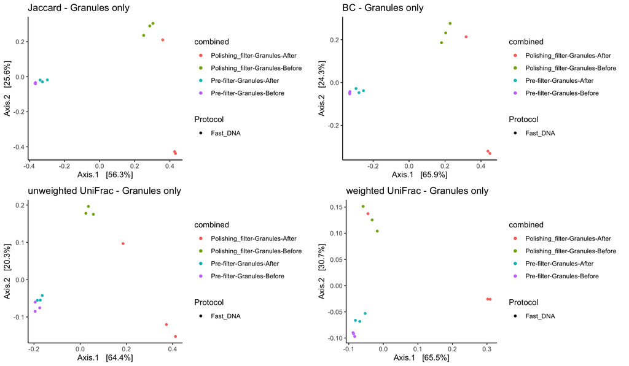

```r
plot_PCoA_BC_noH2O <- plot_ordination(physeq = psdata_OBER_rare_noH2O,
                                ordination = PCoA_BC_noH2O,
                                type = "samples", axes = c(1,2), color = "combined", shape = "Protocol") + ggtitle("BC - Granules only") + theme_classic()
plot_PCoA_Jac_noH2O <- plot_ordination(physeq = psdata_OBER_rare_noH2O,
                                 ordination = PCoA_Jac_noH2O,
                                 type = "samples", axes = c(1,2), color = "combined", shape = "Protocol") + ggtitle("Jaccard - Granules only") + theme_classic()
plot_PCoA_uu_noH2O <- plot_ordination(physeq = psdata_OBER_rare_noH2O,
                                ordination = PCoA_uu_noH2O,
                                type = "samples", axes = c(1,2), color = "combined", shape = "Protocol") + ggtitle("unweighted UniFrac - Granules only") + theme_classic()
plot_PCoA_wu_noH2O <- plot_ordination(physeq = psdata_OBER_rare_noH2O,
                                ordination = PCoA_wu_noH2O,
                                type = "samples", axes = c(1,2), color = "combined", shape = "Protocol") + ggtitle("weighted UniFrac - Granules only") + theme_classic()

beta_plot = cowplot::plot_grid(plot_PCoA_Jac_noH2O, plot_PCoA_BC_noH2O, plot_PCoA_uu_noH2O, plot_PCoA_wu_noH2O, nrow=2, ncol=2)
beta_plot
```

```r
pdf("figures/Fig_S3_plot_beta_diversity_OBER_proj1_BODAC_Granules_only_rare16865.pdf", useDingbats = F, width = 10, height = 5)
beta_plot
dev.off()
```

Backwashing seems to affect the community composition of granule biofilm slightly, washing out particular bacterial lineages as the effects are most clear in weighted and unweighted UniFrac ordinations, and particularly in polishing filters.

```r
dist_bc_noH2O <- distance(psdata_OBER_rare_noH2O , "bray")
dist_jac_noH2O <- distance(psdata_OBER_rare_noH2O, "jaccard", binary=T)
dist_uu_noH2O <- distance(psdata_OBER_rare_noH2O,  "uunifrac")
dist_wu_noH2O <- distance(psdata_OBER_rare_noH2O,  "wunifrac")


# test model assumptions with vegan::betadisper
metadata2_noH2O$dummy_betadisp_noH2O <- factor(paste0(metadata2_noH2O$Filter_type, "-",metadata2_noH2O$Time, "-", metadata2_noH2O$Protocol))

betadisper_jac_noH2O <- betadisper(dist_jac_noH2O,metadata2_noH2O$dummy_betadisp_noH2O)
anova(betadisper_jac_noH2O) %>% broom::tidy() %>% kableExtra::kbl(caption = "Dispersion Jaccard distance") %>% kableExtra::kable_minimal()
```

Dispersion Jaccard distance

| term | df | sumsq | meansq | statistic | p.value |
| --- | --- | --- | --- | --- | --- |
| Groups | 3 | 0.0379640 | 0.0126547 | 1.889544 | 0.2097883 |
| Residuals | 8 | 0.0535777 | 0.0066972 | NA | NA |

```r
betadisper_bc_noH2O <- betadisper(dist_bc_noH2O,metadata2_noH2O$dummy_betadisp_noH2O)
anova(betadisper_bc_noH2O) %>% broom::tidy() %>% kableExtra::kbl(caption = "Dispersion Bray-Curtis dissimilarity") %>% kableExtra::kable_minimal()
```

Dispersion Bray-Curtis dissimilarity

| term | df | sumsq | meansq | statistic | p.value |
| --- | --- | --- | --- | --- | --- |
| Groups | 3 | 0.0740827 | 0.0246942 | 1.104427 | 0.4022105 |
| Residuals | 8 | 0.1788745 | 0.0223593 | NA | NA |

```r
betadisper_uu_noH2O <- betadisper(dist_uu_noH2O,metadata2_noH2O$dummy_betadisp_noH2O)
anova(betadisper_uu_noH2O) %>% broom::tidy() %>% kableExtra::kbl(caption = "Dispersion unweighted UniFrac") %>% kableExtra::kable_minimal()
```

Dispersion unweighted UniFrac

| term | df | sumsq | meansq | statistic | p.value |
| --- | --- | --- | --- | --- | --- |
| Groups | 3 | 0.0175156 | 0.0058385 | 1.52668 | 0.2806267 |
| Residuals | 8 | 0.0305946 | 0.0038243 | NA | NA |

```r
betadisper_wu_noH2O <- betadisper(dist_wu_noH2O,metadata2_noH2O$dummy_betadisp_noH2O)
anova(betadisper_wu_noH2O) %>% broom::tidy() %>% kableExtra::kbl(caption = "Dispersion weighted UniFrac") %>% kableExtra::kable_minimal()
```

Dispersion weighted UniFrac

| term | df | sumsq | meansq | statistic | p.value |
| --- | --- | --- | --- | --- | --- |
| Groups | 3 | 0.0308079 | 0.0102693 | 0.8737645 | 0.4938565 |
| Residuals | 8 | 0.0940235 | 0.0117529 | NA | NA |

```r
## for all four beta diversity metrics no significant group differences were found in group dispersions (distance to centroid).

# PERMANOVA (permutational multivariate analysis of variance) with the 'adonis' function

adonis_jac_noH2O <- adonis2(dist_jac_noH2O ~ Filter_type + Time , permutations = 999, data = metadata2_noH2O, by = "margin")
adonis_jac_noH2O %>% broom::tidy() %>% kableExtra::kbl(caption = "Jaccard distance") %>% kableExtra::kable_minimal()
```

Jaccard distance

| term | df | SumOfSqs | R2 | statistic | p.value |
| --- | --- | --- | --- | --- | --- |
| Filter_type | 1 | 0.9976360 | 0.5261688 | 13.316876 | 0.001 |
| Time | 1 | 0.2241654 | 0.1182284 | 2.992257 | 0.052 |
| Residual | 9 | 0.6742365 | 0.3556028 | NA | NA |
| Total | 11 | 1.8960379 | 1.0000000 | NA | NA |

```r
adonis_bc_noH2O <- adonis2(dist_bc_noH2O ~ Filter_type + Time , permutations = 999, data = metadata2_noH2O, by = "margin")
adonis_bc_noH2O %>% broom::tidy() %>% kableExtra::kbl(caption = "Bray-Curtis dissimilarity") %>% kableExtra::kable_minimal()
```

Bray-Curtis dissimilarity

| term | df | SumOfSqs | R2 | statistic | p.value |
| --- | --- | --- | --- | --- | --- |
| Filter_type | 1 | 1.1250099 | 0.6296034 | 20.83051 | 0.001 |
| Time | 1 | 0.1757748 | 0.0983711 | 3.25462 | 0.080 |
| Residual | 9 | 0.4860701 | 0.2720255 | NA | NA |
| Total | 11 | 1.7868548 | 1.0000000 | NA | NA |

```r
adonis_uu_noH2O <- adonis2(dist_uu_noH2O ~ Filter_type + Time , permutations = 999, data = metadata2_noH2O, by = "margin")
adonis_uu_noH2O %>% broom::tidy() %>% kableExtra::kbl(caption = "unweighted UniFrac") %>% kableExtra::kable_minimal()
```

unweighted UniFrac

| term | df | SumOfSqs | R2 | statistic | p.value |
| --- | --- | --- | --- | --- | --- |
| Filter_type | 1 | 0.4410637 | 0.5196011 | 13.482593 | 0.001 |
| Time | 1 | 0.1133647 | 0.1335509 | 3.465374 | 0.033 |
| Residual | 9 | 0.2944221 | 0.3468480 | NA | NA |
| Total | 11 | 0.8488506 | 1.0000000 | NA | NA |

```r
adonis_wu_noH2O <- adonis2(dist_wu_noH2O ~ Filter_type + Time , permutations = 999, data = metadata2_noH2O, by = "margin")
adonis_wu_noH2O %>% broom::tidy() %>% kableExtra::kbl(caption = "weighted UniFrac") %>% kableExtra::kable_minimal()
```

weighted UniFrac

| term | df | SumOfSqs | R2 | statistic | p.value |
| --- | --- | --- | --- | --- | --- |
| Filter_type | 1 | 0.1426548 | 0.4069136 | 8.143197 | 0.001 |
| Time | 1 | 0.0502583 | 0.1433586 | 2.868907 | 0.049 |
| Residual | 9 | 0.1576645 | 0.4497278 | NA | NA |
| Total | 11 | 0.3505776 | 1.0000000 | NA | NA |

#### Venn diagramm for co-occurrence and co-exclusion patterns

```r
# from https://rdrr.io/github/Russel88/MicEco/man/ps_venn.html
source("scripts/ps_venn.r")

psdata_OBER_rare_noPolFilAftBackw <- subset_samples(psdata_OBER_rare, combined != "Polishing_filter-Granules-After")
psdata_OBER_rare_0.01 <- prune_taxa(taxa_sums(psdata_OBER_rare) > 0.0001, psdata_OBER_rare)
psdata_OBER_rare_noPolFilAftBackw_0.01 <- prune_taxa(taxa_sums(psdata_OBER_rare_noPolFilAftBackw) > 0.0001, psdata_OBER_rare_noPolFilAftBackw)
psdata_OBER_rare_noPolFilAftBackw_0.1 <- prune_taxa(taxa_sums(psdata_OBER_rare_noPolFilAftBackw) > 0.001, psdata_OBER_rare_noPolFilAftBackw)
psdata_OBER_rare_noPolFilAftBackw_0.5 <- prune_taxa(taxa_sums(psdata_OBER_rare_noPolFilAftBackw) > 0.005, psdata_OBER_rare_noPolFilAftBackw)

mean(sample_sums(psdata_OBER_rare_noPolFilAftBackw))
```

```
## [1] 16864.6
```

```r
mean(sample_sums(psdata_OBER_rare_noPolFilAftBackw_0.01))
```

```
## [1] 16864.6
```

```r
mean(sample_sums(psdata_OBER_rare_noPolFilAftBackw_0.1))
```

```
## [1] 16864.6
```

```r
mean(sample_sums(psdata_OBER_rare_noPolFilAftBackw_0.5))
```

```
## [1] 16864.6
```

```r
ntaxa(psdata_OBER_rare_noPolFilAftBackw)
```

```
## [1] 1615
```

```r
ntaxa(psdata_OBER_rare_noPolFilAftBackw_0.01)
```

```
## [1] 1601
```

```r
ntaxa(psdata_OBER_rare_noPolFilAftBackw_0.1)
```

```
## [1] 1601
```

```r
ntaxa(psdata_OBER_rare_noPolFilAftBackw_0.5)
```

```
## [1] 1601
```

```r
# plot rankabundance
source("scripts/amp_rankabundance.r")
#devtools::source_gist("8d0ca4206a66be7ff6d76fc4ab8e66c6")

# #go convert --> STILL TO WORK ON
# sample_data(psdata_OBER_rare_noPolFilAftBackw)$'Sample ID' <- sample_names(psdata_OBER_rare_noPolFilAftBackw)
# ncol(sample_data(psdata_OBER_rare_noPolFilAftBackw))
# colnames(sample_data(psdata_OBER_rare_noPolFilAftBackw))
# sample_data(psdata_OBER_rare_noPolFilAftBackw)[,c(13, 1:11)]
# ampvis2_obj <- phyloseq_to_ampvis2(psdata_OBER_rare_noPolFilAftBackw)
# amp_rankabundance(ampvis2_obj, group_by = "combined", showSD = TRUE, log10_x = F)


venn_count_0.01 <-
ps_venn(ps = psdata_OBER_rare_noPolFilAftBackw_0.01,
        group = 'Protocol',
        fraction = 0,
        weight = F,
        type = "percent",
        rareative = F,
        plot = T)

venn_count_0.01_count <-
ps_venn(ps = psdata_OBER_rare_noPolFilAftBackw_0.01,
        group = 'Protocol',
        fraction = 0,
        weight = F,
        type = "counts",
        rareative = F,
        plot = T)

venn_count_0.01_genus <-
ps_venn(ps = tax_glom(psdata_OBER_rare_noPolFilAftBackw_0.01, "Genus"),
        group = 'Protocol',
        fraction = 0,
        weight = F,
        type = "percent",
        rareative = F,
        plot = T)

ps_granule <- subset_samples(psdata_OBER_rare_0.01, Sample_type == "Granules")
ps_granule_FS <- subset_samples(ps_granule, Protocol == "Fast_DNA")
ps_granule_pre <- prune_taxa(taxa_sums(subset_samples(ps_granule_FS, Filter_type == "Pre-filter")) > 0, subset_samples(ps_granule_FS, Filter_type == "Pre-filter"))
ps_granule_polish <-  prune_taxa(taxa_sums(subset_samples(ps_granule_FS, Filter_type == "Polishing_filter")) > 0, subset_samples(ps_granule_FS, Filter_type == "Polishing_filter"))


venn_count_0.01_Time_pre <-
ps_venn(ps = ps_granule_pre,
        group = 'Time',
        fraction = 0,
        weight = F,
        type = "percent",
        rareative = F,
        plot = T)

venn_count_0.01_Time_polish <-
ps_venn(ps = ps_granule_polish,
        group = 'Time',
        fraction = 0,
        weight = F,
        type = "percent",
        rareative = F,
        plot = T)

pdf("figures/plot_venn_diagram_OBER_proj1_BODAC_Protocols_none_0.001_0.01_0.5pct.pdf", useDingbats = F, width = 7, height = 13)
gridExtra::grid.arrange(venn_count_0.01_Time_pre, venn_count_0.01_Time_polish, nrow=2, ncol=1)
dev.off()
```

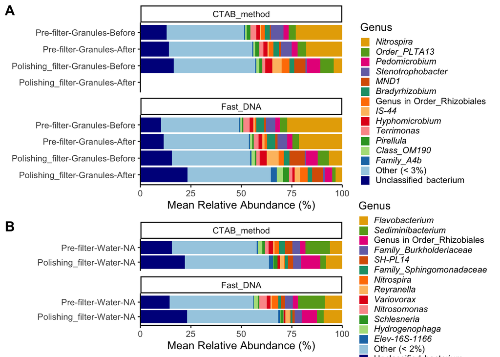

```r
# set colorset
colorset <- c("darkblue", "darkgoldenrod1", "darkseagreen", "darkorchid", "darkolivegreen1", "lightskyblue", "darkgreen",  "khaki2", "firebrick", "brown1", "darkorange1", "cyan1", "royalblue4", "darksalmon", "darkblue", "royalblue4", "dodgerblue3", "steelblue1", "lightskyblue", "darkseagreen", "darkgoldenrod1", "darkseagreen", "darkorchid", "darkolivegreen1", "brown1", "darkorange1", "cyan1", "darkgrey", "darkblue", "darkgoldenrod1", "darkseagreen", "darkorchid", "darkolivegreen1", "lightskyblue", "darkgreen", "deeppink", "khaki2", "firebrick", "brown1", "darkorange1", "cyan1", "royalblue4", "darksalmon", "darkblue", "royalblue4", "dodgerblue3", "steelblue1", "lightskyblue", "darkseagreen", "darkgoldenrod1", "darkseagreen", "darkorchid", "darkolivegreen1", "brown1", "darkorange1", "cyan1", "darkgrey")


#input data
ps_Genus_rare <- psmelt(transform_sample_counts(tax_glom(psdata_OBER_rare, "Genus"), fun = function(x) x/sum(x)))

Genus_abundances <- ps_Genus_rare %>%
  as_tibble() %>%
  select(Sample, Sample_type, Filter_type, Protocol, Time, combined, Genus, Abundance) %>%
  mutate(combined = as.character(combined)) %>%
  group_by(Sample, combined, Genus) %>%
  summarize(rel_abund = sum(Abundance), .groups = "drop") %>%
  group_by(combined, Genus) %>%
  summarize(mean_rel_abund = 100* mean(rel_abund), .groups = "drop") %>%
  mutate(Family = if_else(Family == "uncultured", paste0("Family in ", Order), Family)) %>%
  mutate(Genus = if_else(Genus == "Family_uncultured", paste0("Genus in ", Order), Genus)) %>%
  mutate(Genus = str_replace(Genus, "(.*)_unclassified", "Unclassified *\\1*"),
         Genus = str_replace(Genus, "uncultured$", "Unclassified bacterium"),
         Genus = str_replace(Genus, "^(\\S*)$", "*\\1*"))

Genus_abundances_granules <- ps_Genus_rare %>%
  as_tibble() %>%
  select(Sample, Sample_type, Filter_type, Protocol, Time, combined, Genus, Abundance) %>%
  mutate(combined = as.character(combined)) %>%
  group_by(Sample, Sample_type, Protocol, combined, Genus) %>%
  filter(Sample_type == "Granules") %>%
  summarize(rel_abund = sum(Abundance), .groups = "drop") %>%
  group_by(combined, Protocol, Genus) %>%
  summarize(mean_rel_abund = 100* mean(rel_abund), .groups = "drop") %>%
  mutate(Family = if_else(Family == "uncultured", paste0("Family in ", Order), Family)) %>%
  mutate(Genus = if_else(Genus == "Family_uncultured", paste0("Genus in ", Order), Genus)) %>%
  mutate(Genus = str_replace(Genus, "(.*)_unclassified", "Unclassified *\\1*"),
         Genus = str_replace(Genus, "uncultured$", "Unclassified bacterium"),
         Genus = str_replace(Genus, "^(\\S*)$", "*\\1*"))

Genus_abundances_BW <- ps_Genus_rare %>%
  as_tibble() %>%
  select(Sample, Sample_type, Filter_type, Protocol, Time, combined, Genus, Abundance) %>%
  mutate(combined = as.character(combined)) %>%
  group_by(Sample, Sample_type, Protocol, combined, Genus) %>%
  filter(Sample_type == "Water") %>%
  summarize(rel_abund = sum(Abundance), .groups = "drop") %>%
  group_by(combined, Protocol, Genus) %>%
  summarize(mean_rel_abund = 100* mean(rel_abund), .groups = "drop") %>%
  mutate(Family = if_else(Family == "uncultured", paste0("Family in ", Order), Family)) %>%
  mutate(Genus = if_else(Genus == "Family_uncultured", paste0("Genus in ", Order), Genus)) %>%
  mutate(Genus = str_replace(Genus, "(.*)_unclassified", "Unclassified *\\1*"),
         Genus = str_replace(Genus, "uncultured$", "Unclassified bacterium"),
         Genus = str_replace(Genus, "^(\\S*)$", "*\\1*"))

Genus_pool <- Genus_abundances %>%
  group_by(Genus) %>%
  summarize(pool = max(mean_rel_abund) < 5,
            mean = mean(mean_rel_abund),
            .groups = "drop")

Genus_pool_granules <- Genus_abundances_granules %>%
  group_by(Genus) %>%
  summarize(pool = max(mean_rel_abund) < 3,
            mean = mean(mean_rel_abund),
            .groups = "drop")

Genus_pool_BW <- Genus_abundances_BW %>%
  group_by(Genus) %>%
  summarize(pool = max(mean_rel_abund) < 2,
            mean = mean(mean_rel_abund),
            .groups = "drop")

library(RColorBrewer)

# barplot granules only
barplot_granules <-
inner_join(Genus_abundances_granules, Genus_pool_granules, by="Genus") %>%
  mutate(Genus = if_else(pool, "Other (< 3%)", Genus)) %>%
  group_by(combined, Protocol, Genus) %>%
  summarize(mean_rel_abund = sum(mean_rel_abund),
            mean = min(mean),
            .groups = "drop") %>%
  mutate(Genus = factor(Genus),
         Genus = fct_reorder(Genus, mean, .desc = T),
         Genus = fct_shift(Genus, n=1)) %>%
ggplot(aes(x=combined, y = mean_rel_abund, fill = Genus)) +
  geom_col() +
  scale_y_continuous(expand = c(0,0)) +
  labs(x=NULL, y="Mean Relative Abundance (%)") +
  scale_fill_manual(name="Genus",
                    values = c(rev(brewer.pal(6, "Dark2")), rev(brewer.pal(8, "Paired")), colorset)) +
  theme_classic() +
  theme(axis.text.x = element_markdown(),
        legend.text = element_markdown(),
        legend.key.size = unit(10, "pt")) +
  facet_wrap(~Protocol, nrow = 2) +
  coord_flip()

# barplot backwash water only
BW_barplot <-
inner_join(Genus_abundances_BW, Genus_pool_BW, by="Genus") %>%
  mutate(Genus = if_else(pool, "Other (< 2%)", Genus)) %>%
  group_by(combined, Protocol, Genus) %>%
  summarize(mean_rel_abund = sum(mean_rel_abund),
            mean = min(mean),
            .groups = "drop") %>%
  mutate(Genus = factor(Genus),
         Genus = fct_reorder(Genus, mean, .desc = T),
         Genus = fct_shift(Genus, n=1)) %>%
ggplot(aes(x=combined, y = mean_rel_abund, fill = Genus)) +
  geom_col() +
  scale_y_continuous(expand = c(0,0)) +
  labs(x=NULL, y="Mean Relative Abundance (%)") +
  facet_wrap(~Protocol, nrow = 2) +
  scale_fill_manual(name="Genus",
                    values = c(rev(brewer.pal(6, "Dark2")), rev(brewer.pal(8, "Paired")), colorset)) +
  theme_classic() +
  theme(axis.text.x = element_markdown(),
        legend.text = element_markdown(),
        legend.key.size = unit(10, "pt")) +
  coord_flip()




bars = plot_grid(barplot_granules, BW_barplot, labels = c("A", "B"), align = "hv", nrow = 2, rel_heights = c(2, 1.3))
ggsave(bars, filename = "figures/plot_barplots_genus_OBER_rare16865.pdf", width = 8, height = 8)
bars
```

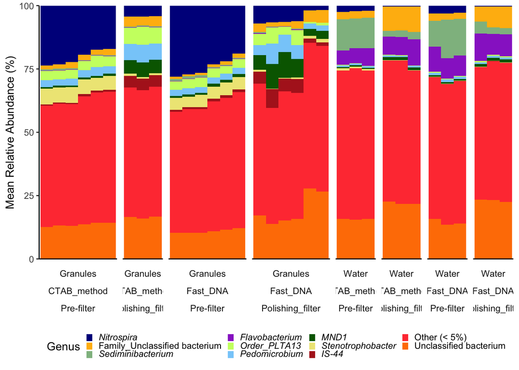

```r
Genus_abundances_sample <- ps_Genus_rare %>%
  as_tibble() %>%
  select(Sample, Sample_type, Filter_type, Protocol, Time, combined, Genus, Abundance) %>%
  mutate(combined = as.character(combined)) %>%
  group_by(Protocol, Sample_type, Filter_type, Sample, combined, Genus) %>%
  summarize(rel_abund = sum(Abundance), .groups = "drop") %>%
  group_by(Protocol, Sample_type, Filter_type, Sample, combined, Genus) %>%
  summarize(mean_rel_abund = 100* mean(rel_abund), .groups = "drop") %>%
  mutate(Genus = str_replace(Genus, "(.*)_unclassified", "Unclassified *\\1*"),
         Genus = str_replace(Genus, "uncultured$", "Unclassified bacterium"),
         Genus = str_replace(Genus, "^(\\S*)$", "*\\1*"))


Genus_pool_sample <- Genus_abundances_sample %>%
  group_by(Sample, Sample_type, Filter_type, combined, Protocol, Genus) %>%
  summarize(mean = mean(mean_rel_abund), .groups = "drop") %>%
  group_by(Genus) %>%
  summarize(pool = max(mean) < 5,
            mean = mean(mean),
            .groups = "drop")

sample_order <- Genus_abundances_sample %>%
  filter(Genus ==  "*Nitrospira*") %>%
  arrange(desc(mean_rel_abund)) %>%
  mutate(order = 1:nrow(.)) %>%
  select(Sample, order)


inner_join(Genus_abundances_sample, Genus_pool_sample, by="Genus") %>%
  mutate(Genus = if_else(pool, "Other (< 5%)", Genus)) %>%
  group_by(Protocol, Sample, Sample_type, Filter_type, combined, Genus) %>%
  summarize(rel_abund = sum(mean_rel_abund),
            mean = min(mean),
            .groups = "drop") %>%
  mutate(Genus = factor(Genus),
         Genus = fct_reorder(Genus, mean, .desc = T),
         Genus = fct_shift(Genus, n=1)) %>%
  inner_join(., sample_order, by = "Sample") %>%
  mutate(Sample = factor(Sample),
         Sample = fct_reorder(Sample, order),
         Filter_type = fct_relevel(Filter_type, "Pre-filter")) %>%
ggplot(aes(x=Sample, y = rel_abund, fill = Genus)) +
  geom_col(width = 1) +
  scale_fill_manual(name="Genus",
                    values = colorset) +
                        # breaks = c("*Geobacter*",
                        #            "*Dysgonomonas*",
                        #            "*Dechlorosoma*",
                        #            "*Leptolinea*",
                        #            "*Proteiniphilum*",
                        #            "*Petrimonas*",
                        #            "*Family_PHOS-HE36*",
                        #            "Unclassified bacterium",
                        #            "Other (< 5%)"),
                        # values = c(brewer.pal(8,"Paired"),"grey")) + # with palette
                        # #values = colorset) +
  scale_y_continuous(expand = c(0,0)) +
  facet_grid(~Sample_type+Protocol+Filter_type, space = "free", scales = "free_x", switch = "x") +
  labs(x=NULL, y="Mean Relative Abundance (%)") +
  guides(fill = guide_legend(nrow = 3, byrow = F)) +
  theme_classic() +
  theme(axis.text.x = element_blank(),
        legend.text = element_markdown(),
        legend.key.size = unit(7, "pt"),
        axis.ticks.x = element_blank(),
        strip.background = element_blank(),
        strip.placement = "outside",
        legend.position = "bottom")
```

```r
ggsave("figures/OBER_stacked_barplot_Genus_samplewise_.pdf", width = 7, height = 4, units = "in")
```